# zds - ligue 1

Dernière mise à jour le Thu Jun 8 09:45:21 2017

Bienvenue sur la page du jeu *zdsbet* joué sur le forum [zeste de savoir](http://zestedesavoir.com). Le jeu consiste à trouver un système, un algorithme ou à suivre son instinct pour prédire l’issue des matchs de football de ligue 1. Tous les joueurs prédisent les issues des 10 matchs de chaque journée de championnat. Un algorithme tente ensuite de faire une prédiction en utilisant toutes les prédictions des joueurs, pondérées par les performances passées. Les prédictions de l’algorithme sont enregistrées sous le nom du joueur *Clem*.

Pour rejoindre le jeu, inscrivez-vous sur le forum http://zestedesavoir.com et participez au sujet [Atelier Paris sportifs et intelligence collective](https://zestedesavoir.com/forums/sujet/999/atelier-paris-sportifs-et-intelligence-collective/).

Le programme (écrit en R) est accessible sur [github](https://github.com/adndebanane/zdsbets).

# Pronostiqueurs

| Joueur | Gains | Poids | Nb de victoires | Ratio de Victoires | Nb de matchs |
| --- | --- | --- | --- | --- | --- |
| Urgau | 71.5 | 0.000613891829623282 | 6 | 0.6 | 10 |
| Bouli1515 | 121.2 | 0.00106539338403242 | 23 | 0.575 | 40 |
| adndebanane_elo | 48.7 | 0.00144010645851639 | 51 | 0.51 | 100 |
| Ricocotam | 76.7 | 0.000862628203912617 | 30 | 0.5 | 60 |
| Matchaos | -4.20000000000005 | 0.000698453199858491 | 37 | 0.4625 | 80 |
| adndebanane | -57 | 0.000738643470711822 | 46 | 0.46 | 100 |
| Emeric | -21.3 | 0.000525657739473245 | 22 | 0.44 | 50 |
| Clem | -186 | 0.0004329792414988 | 42 | 0.42 | 100 |
| Rockaround | -122.9 | 0.000372412949678292 | 28 | 0.4 | 70 |
| mrBen | -145.9 | 8.720948293421e-05 | 30 | 0.3 | 100 |

[output cut: 2 more lines]

# Championnat

Cette saison il y a eu 48.9473684% de victoires à domicile, 24.7368421% de matchs nuls et 26.3157895% de victoire à l’extérieur (contre respectivement 45.7236842%, 26.1842105% et 28.0921053% depuis la saison 2013/2014).

## Tous les résultats de la saison de ligue 1 2016-2017

| Date | Domicile | Visiteurs | ButDomicile | ButVisiteurs | Resultat |
| --- | --- | --- | --- | --- | --- |
| 2017-05-20 | Angers | Montpellier | 2 | 0 | 1 |
| 2017-05-20 | Guingamp | Metz | 1 | 0 | 1 |
| 2017-05-20 | Lille | Nantes | 3 | 0 | 1 |
| 2017-05-20 | Lorient | Bordeaux | 1 | 1 | N |
| 2017-05-20 | Lyon | Nice | 3 | 3 | N |
| 2017-05-20 | Marseille | Bastia | 1 | 0 | 1 |
| 2017-05-20 | Nancy | St Etienne | 3 | 1 | 1 |
| 2017-05-20 | Paris SG | Caen | 1 | 1 | N |
| 2017-05-20 | Rennes | Monaco | 2 | 3 | 2 |
| 2017-05-20 | Toulouse | Dijon | 0 | 0 | N |

[output cut: 370 more lines]

## Classement de la ligue 1

| Classement | Equipes | MatchJoues | Gagnes | Nuls | Perdus | ButsPour | ButsContre | DiffButs | Pts |
| --- | --- | --- | --- | --- | --- | --- | --- | --- | --- |
| 1 | Monaco | 38 | 30 | 5 | 3 | 107 | 31 | 76 | 95 |
| 2 | Paris SG | 38 | 27 | 6 | 5 | 83 | 27 | 56 | 87 |
| 3 | Nice | 38 | 22 | 12 | 4 | 63 | 36 | 27 | 78 |
| 4 | Lyon | 38 | 21 | 4 | 13 | 80 | 48 | 32 | 67 |
| 5 | Marseille | 38 | 17 | 11 | 10 | 57 | 41 | 16 | 62 |
| 6 | Bordeaux | 38 | 15 | 14 | 9 | 53 | 43 | 10 | 59 |
| 7 | Nantes | 38 | 14 | 9 | 15 | 40 | 54 | -14 | 51 |
| 8 | St Etienne | 38 | 12 | 14 | 12 | 41 | 42 | -1 | 50 |
| 9 | Rennes | 38 | 12 | 14 | 12 | 36 | 42 | -6 | 50 |
| 10 | Guingamp | 38 | 14 | 8 | 16 | 46 | 53 | -7 | 50 |

[output cut: 10 more lines]

## Prochains matchs

| Domicile | Visiteur |
| --- | --- |

## Classement Elo

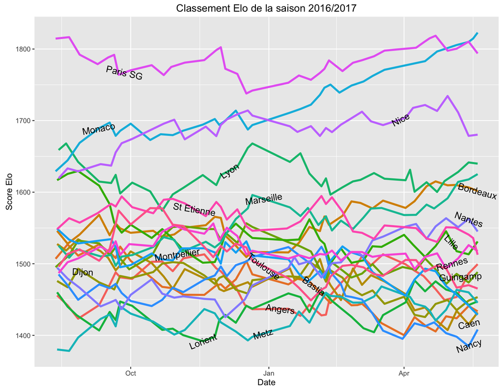

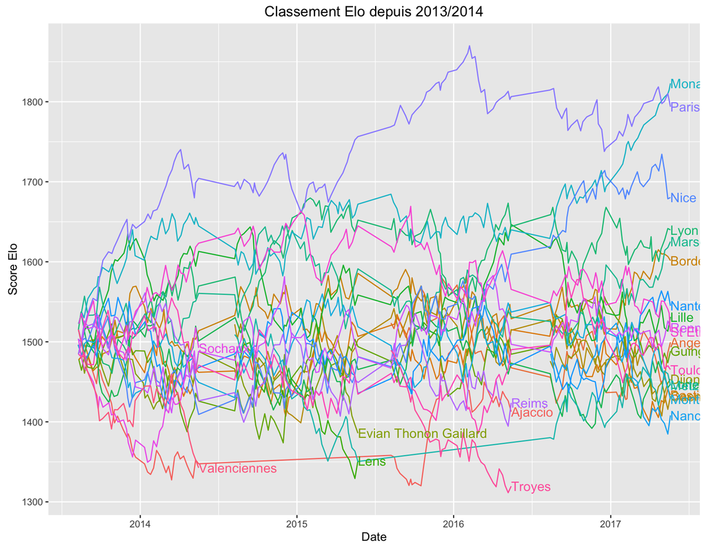

# Jeux de données

Tous les jeux de données utilisés sur cette page sont disponibles [sur github](https://github.com/adndebanane/zdsbets/tree/master/00-datasets/20162017). Ils proviennent du site http://www.football-data.co.uk et des utilisateurs du forum http://zestedesavoir.com sur le sujet [Atelier Paris sportifs et intelligence collective](https://zestedesavoir.com/forums/sujet/999/atelier-paris-sportifs-et-intelligence-collective/).